# Three Sources of Endogeneity

Quantitative Economics

Swapnil Singh

# Learning goals

1. See three different ways to create the same problem: $\operatorname{cov}(X_i, u_i) \neq 0$
2. Connect intuitive stories, algebra, and simulation output
3. Learn which settings can be fixed with controls and which ones require something stronger

This notebook is still **pre-IV**. We are learning the problem first. At the end of each section, we give a short preview of how an external source of variation could fix the problem, but the formal IV lecture comes later.

# One framework, three mechanisms

We keep returning to the same regression:
$$Y_i = \beta_0 + \beta_1 X_i + u_i.$$

OLS needs $X_i$ to be unrelated to the hidden term $u_i$. The three mechanisms below break that requirement in different ways:

| Source | What goes wrong? | Why does $X$ become correlated with $u$? |
| --- | --- | --- |
| Omitted variable | Something relevant is left out | The omitted factor affects both $X$ and $Y$ |
| Measurement error | We observe a noisy version of $X$ | The noise contaminates both the regressor and the error |
| Simultaneity | $X$ and $Y$ are jointly chosen | The regressor already responds to shocks in the outcome equation |

# Global parameters

```r
sample_size <- 400
mc_reps     <- 700
```

# 1. Omitted Variable Bias

## Intuition

Suppose we want to estimate the effect of schooling on earnings, but we omit ability.

- ability affects earnings directly
- ability also affects schooling

Then ability is hidden inside $u$, and the regressor $X$ inherits part of it.

## Algebra

True model:
$$Y_i = \beta_0 + \beta_1 X_i + \beta_2 W_i + \varepsilon_i$$

Estimated short regression:
$$Y_i = \beta_0 + \beta_1 X_i + u_i, \quad u_i = \beta_2 W_i +
\varepsilon_i$$

Therefore,
$$\operatorname{cov}(X_i, u_i) = \beta_2 \operatorname{cov}(X_i, W_i).$$

Omitted variable bias disappears if either:

- the omitted factor does not matter for $Y$ ($\beta_2 = 0$)
- the omitted factor is unrelated to $X$ ($\rho_{XW} = 0$)

## Single sample

```r
ovb_params <- list(
  n                   = sample_size,
  beta_x              = 1.0,
  beta_w              = 1.5,
  rho_xw              = 0.8,
  instrument_strength = 0.9,
  x_noise_sd          = 1.0
)
```

```r
ovb_result <- do.call(ovb_one_run, c(ovb_params, seed = 2026))

knitr::kable(ovb_result$summary, digits = 3)
```

| Estimator | Estimate |
| --- | --- |
| Truth | 1.000 |
| Theory: OLS omit W | 1.490 |
| OLS omit W | 1.518 |
| OLS control for W | 1.026 |
| IV using Z | 0.947 |
| corr(X, W) | 0.536 |

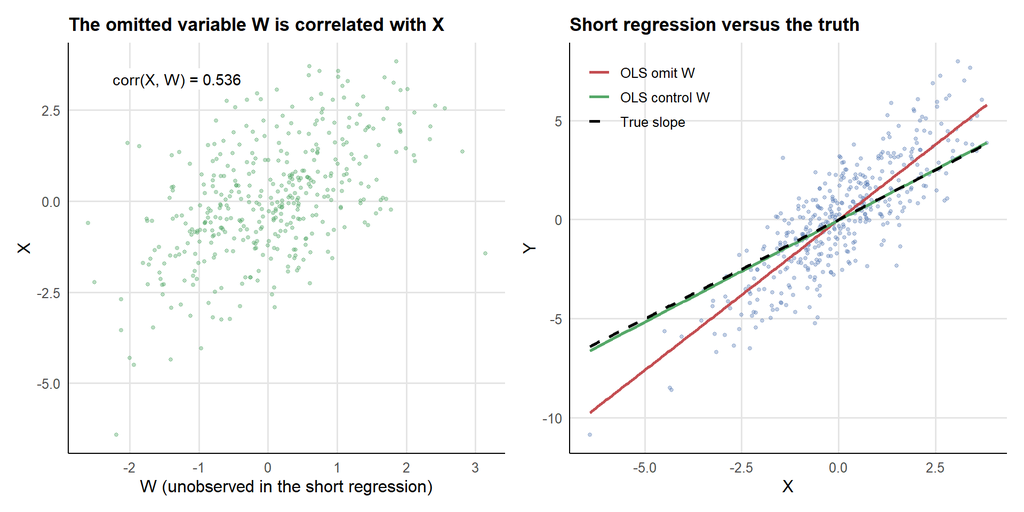

```r
plot_ovb_sample(ovb_result$data, beta_x = ovb_params$beta_x)
```

Read the snapshot like this:

- `OLS omit W` is the biased short regression
- `OLS control for W` is the clean benchmark when the omitted variable becomes observable
- `IV using Z` is only a preview for later: if we had a clean shifter $Z$, it could also isolate variation in $X$ that is unrelated to $W$

If you want to turn off omitted-variable bias and verify the theory, set `rho_xw = 0` or `beta_w = 0` and rerun.

## Monte Carlo

```r
ovb_mc      <- do.call(mc_ovb, c(ovb_params, reps = mc_reps, seed = 1))
ovb_summary <- summarize_estimates(ovb_mc, truth = ovb_params$beta_x)

knitr::kable(ovb_summary, digits = 3)
```

| Estimator | Mean | Bias | Std.dev | RMSE |
| --- | --- | --- | --- | --- |
| OLS omit W | 1.492 | 0.492 | 0.050 | 0.494 |
| OLS control W | 0.999 | -0.001 | 0.037 | 0.037 |
| IV using Z | 0.993 | -0.007 | 0.100 | 0.100 |

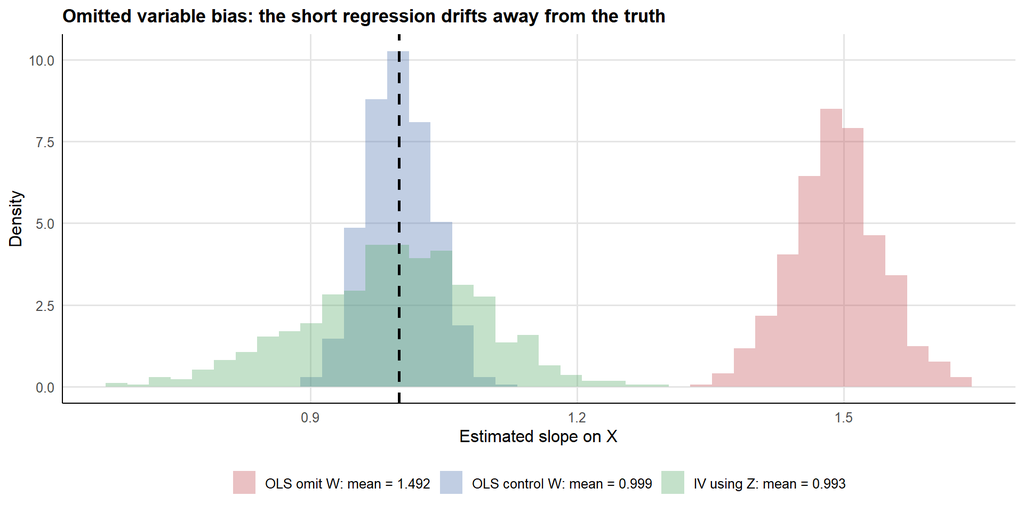

```r
plot_estimate_distributions(
  ovb_mc,
  truth   = ovb_params$beta_x,
  title   = "Omitted variable bias: the short regression drifts away from the truth",
  x_label = "Estimated slope on X"
)
```

# 2. Measurement Error

## Intuition

Sometimes the regressor is conceptually right, but measured badly. Think of self-reported income, hours worked, or wealth.

Let the true regressor be $X_i^*$, but suppose we observe:
$$X_i = X_i^* + w_i.$$

## Algebra

If the true model is
$$Y_i = \beta_0 + \beta_1 X_i^* + \varepsilon_i,$$
then after substituting $X_i^* = X_i - w_i$ we get
$$Y_i = \beta_0 + \beta_1 X_i + (\varepsilon_i - \beta_1 w_i).$$

The new error term contains the measurement noise. So the observed regressor and the error term now overlap mechanically.

Under classical measurement error, OLS is biased toward zero:
$$\hat{\beta}_1^{OLS} \to \beta_1
\frac{\operatorname{var}(X^*)}{\operatorname{var}(X^*) +
\operatorname{var}(w)}.$$

## Single sample

```r
measurement_params <- list(
  n                    = sample_size,
  beta_x               = 1.0,
  instrument_strength  = 0.9,
  latent_noise_sd      = 1.0,
  measurement_noise_sd = 1.1
)
```

```r
me_result <- do.call(measurement_error_one_run,
                     c(measurement_params, seed = 2026))

knitr::kable(me_result$summary, digits = 3)
```

| Estimator | Estimate |
| --- | --- |
| Truth | 1.000 |
| Theory: OLS with noisy X | 0.591 |
| OLS using noisy X | 0.595 |
| OLS using true X* | 0.974 |
| IV using Z | 0.965 |
| corr(X observed, measurement error) | 0.663 |

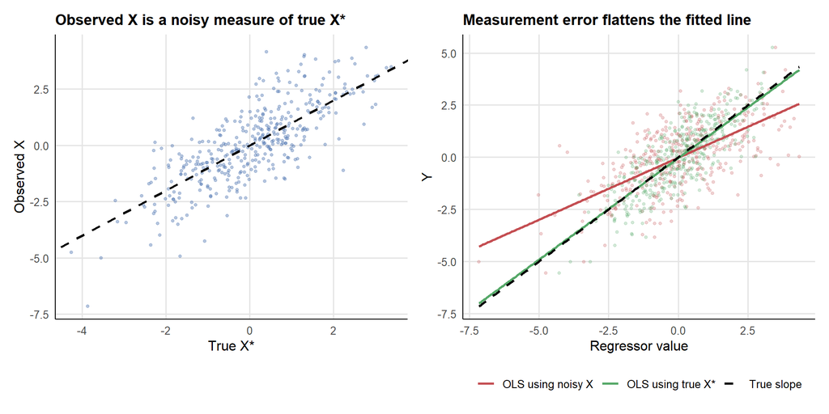

```r
plot_measurement_error_sample(me_result$data,
                              beta_x = measurement_params$beta_x)
```

Focus on the slope estimates:

- `OLS using true X*` is the benchmark we would like to have
- `OLS using noisy X` is flatter because measurement noise pushes the coefficient toward zero
- `IV using Z` is a preview of how an external source of clean variation could recover the true signal

To see attenuation bias disappear, set `measurement_noise_sd = 0` and rerun.

## Monte Carlo

```r
me_mc      <- do.call(mc_measurement_error,
                      c(measurement_params, reps = mc_reps, seed = 2))
me_summary <- summarize_estimates(me_mc, truth = measurement_params$beta_x)

knitr::kable(me_summary, digits = 3)
```

| Estimator | Mean | Bias | Std.dev | RMSE |
| --- | --- | --- | --- | --- |
| OLS using noisy X | 0.600 | -0.400 | 0.039 | 0.402 |
| OLS using true X* | 0.999 | -0.001 | 0.038 | 0.038 |
| IV using Z | 1.006 | 0.006 | 0.086 | 0.086 |

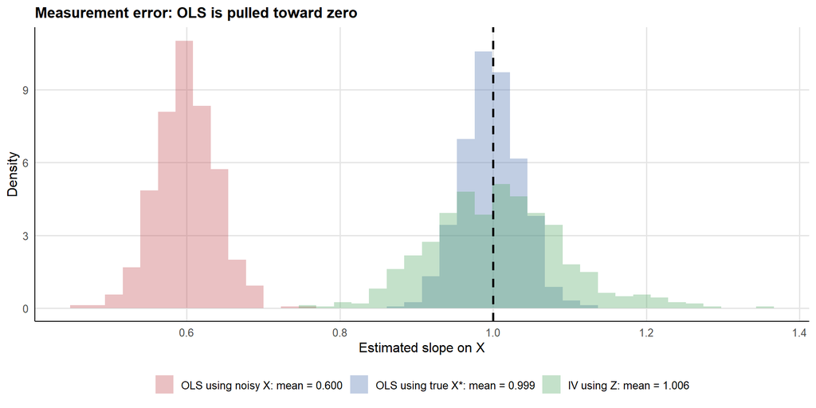

```r
plot_estimate_distributions(
  me_mc,
  truth   = measurement_params$beta_x,
  title   = "Measurement error: OLS is pulled toward zero",
  x_label = "Estimated slope on X"
)
```

# 3. Simultaneity

## Intuition

In supply and demand, price and quantity are determined together. If we run a regression of quantity on price, price is not an outside cause that arrives first. It is an equilibrium outcome.

Demand:
$$Q_i = \alpha_0 + \alpha_1 P_i + u_i^d$$

Supply:
$$Q_i = \gamma_0 + \gamma_1 P_i + \delta Z_i + u_i^s$$

Here $Z$ is a supply shifter. We use it only as a preview device for later.

## Supply and demand identification

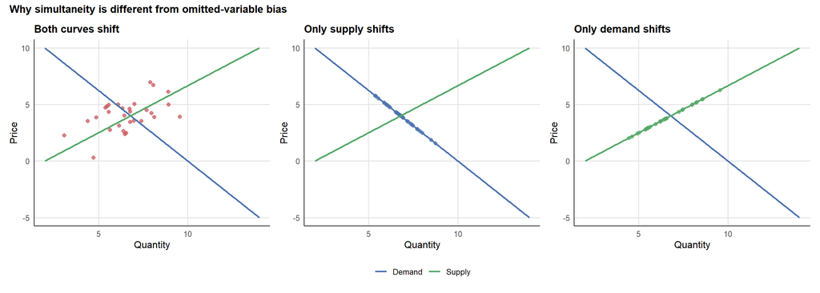

```r
plot_supply_demand_worlds(seed = 2026)
```

The figure above is the key intuition:

- if both supply and demand move, the cloud of equilibrium points does not trace a single structural curve
- if only supply shifts, the equilibrium points trace out demand
- if only demand shifts, the equilibrium points trace out supply

This is why simultaneity is not just another omitted-variable story. The regressor itself is jointly determined inside the system.

## Single sample

```r
simultaneity_params <- list(
  n                   = sample_size,
  demand_intercept    = 10.0,
  demand_slope        = -0.8,
  supply_intercept    = 2.0,
  supply_slope        = 1.2,
  instrument_strength = 1.5,
  demand_shock_sd     = 1.0,
  supply_shock_sd     = 1.0
)
```

```r
sim_result <- do.call(simultaneity_one_run,
                      c(simultaneity_params, seed = 2026))

knitr::kable(sim_result$summary, digits = 3)
```

| Estimator | Estimate |
| --- | --- |
| Truth: demand slope | -0.800 |
| OLS of Q on P | -0.334 |
| IV using supply shifter Z | -0.784 |
| corr(P, demand shock) | 0.472 |
| corr(Z, P) | -0.734 |

The important numbers are:

- `corr(P, demand shock)`: this shows price is endogenous in the demand equation
- `OLS of Q on P`: this does not recover the true demand slope
- `IV using supply shifter Z`: preview of the idea that a variable shifting supply but not demand can identify the demand curve

## Monte Carlo

```r
sim_mc      <- do.call(mc_simultaneity,
                       c(simultaneity_params, reps = mc_reps, seed = 3))
sim_summary <- summarize_estimates(sim_mc,
                                   truth = simultaneity_params$demand_slope)

knitr::kable(sim_summary, digits = 3)
```

| Estimator | Mean | Bias | Std.dev | RMSE |
| --- | --- | --- | --- | --- |
| OLS of Q on P | -0.331 | 0.469 | 0.044 | 0.471 |
| IV using supply shifter Z | -0.805 | -0.005 | 0.072 | 0.072 |

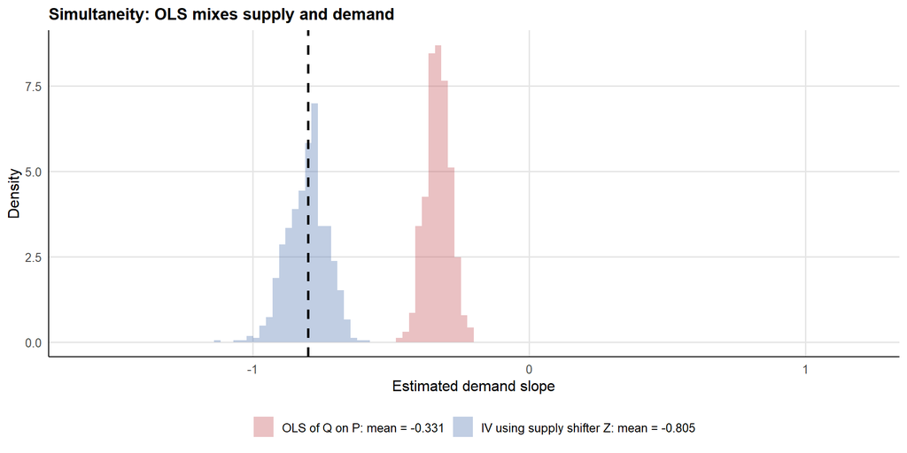

```r
plot_estimate_distributions(
  sim_mc,
  truth      = simultaneity_params$demand_slope,
  title      = "Simultaneity: OLS mixes supply and demand",
  x_label    = "Estimated demand slope",
  xlim_range = c(-1.6, 1.2)
)
```

# Side-by-side comparison

The three cases look different economically, but from the point of view of regression they all create the same symptom: $X$ carries hidden information from the error term.

```r
comparison <- data.frame(
  Source = c("Omitted variable bias", "Measurement error", "Simultaneity"),
  Biased.OLS.mean = c(
    ovb_summary$Mean[ovb_summary$Estimator == "OLS omit W"],
    me_summary$Mean[me_summary$Estimator == "OLS using noisy X"],
    sim_summary$Mean[sim_summary$Estimator == "OLS of Q on P"]
  ),
  Cleaner.estimator.mean = c(
    ovb_summary$Mean[ovb_summary$Estimator == "IV using Z"],
    me_summary$Mean[me_summary$Estimator == "IV using Z"],
    sim_summary$Mean[sim_summary$Estimator == "IV using supply shifter Z"]
  ),
  Truth = c(
    ovb_params$beta_x,
    measurement_params$beta_x,
    simultaneity_params$demand_slope
  )
)

knitr::kable(comparison, digits = 3)
```

| Source | Biased.OLS.mean | Cleaner.estimator.mean | Truth |
| --- | --- | --- | --- |
| Omitted variable bias | 1.492 | 0.993 | 1.0 |
| Measurement error | 0.600 | 1.006 | 1.0 |
| Simultaneity | -0.331 | -0.805 | -0.8 |

# Final takeaways

1. Different economic stories can produce the same econometric symptom: $\operatorname{cov}(X, u) \neq 0$
2. Omitted variables can sometimes be fixed by adding the missing control, if it is observed
3. Measurement error and simultaneity usually need a different source of variation
4. That different source of variation is exactly what the IV lecture is about

If you want a clean classroom exercise, rerun each section with the bias switched off:

- OVB: set `rho_xw = 0`
- Measurement error: set `measurement_noise_sd = 0`
- Simultaneity: set `demand_shock_sd = 0` and inspect how the equilibrium cloud changes